# R Notebook

0. Importations

```r
rm(list = ls())
library(FactoMineR)
library(factoextra)
library(ggplot2)
library(corrplot)
library(ape)
library(caret)
library(funModeling)
library(visdat)
library(dplyr)
library(plyr)
library(ggplot2)
```

1. Loading and preparation of data

```r
options(warn = -1)
setwd("/Users/macbook/Downloads")
```

```
The working directory was changed to /Users/macbook/Downloads inside a notebook chunk. The working directory will be reset when the chunk is finished running. Use the knitr root.dir option in the setup chunk to change the working directory for notebook chunks.
```

```r
file  <- 'Breast_Cancer_Valid.txt'
df   <- read.table(paste0(getwd(),'/',file),header = T)
# View(df)
```

```r
head(df)
```

|  | e_masse | uni_taille | Uni_form | adhesion | teille_epi | noyaux | chromatine | norm_nuclei | mitose | class |
| --- | --- | --- | --- | --- | --- | --- | --- | --- | --- | --- |
| 1 | 5 | 1 | 1 | 1 | 2 | 1 | 3 | 1 | 1 | 2 |
| 2 | 5 | 4 | 4 | 5 | 7 | 10 | 3 | 2 | 1 | 2 |
| 3 | 3 | 1 | 1 | 1 | 2 | 2 | 3 | 1 | 1 | 2 |
| 4 | 6 | 8 | 8 | 1 | 3 | 4 | 3 | 7 | 1 | 2 |
| 5 | 4 | 1 | 1 | 3 | 2 | 1 | 3 | 1 | 1 | 2 |
| 6 | 8 | 10 | 10 | 8 | 7 | 10 | 9 | 7 | 1 | 4 |

The dataset contains 10 variables which describe the characteristics of the cell nuclei :

```r
colnames(df)
```

```
 [1] "e_masse"     "uni_taille"  "Uni_form"    "adhesion"    "teille_epi"  "noyaux"
 [7] "chromatine"  "norm_nuclei" "mitose"      "class"
```

It contains a number of observations of :

```r
nrow(df)
```

```
[1] 699
```

```r
colSums(is.na(df))
```

```
    e_masse  uni_taille    Uni_form    adhesion  teille_epi      noyaux  chromatine
          0           0           0           0           0           0           0
norm_nuclei      mitose       class
          0           0           0
```

Most of the variables have an integer type, except noyaux :

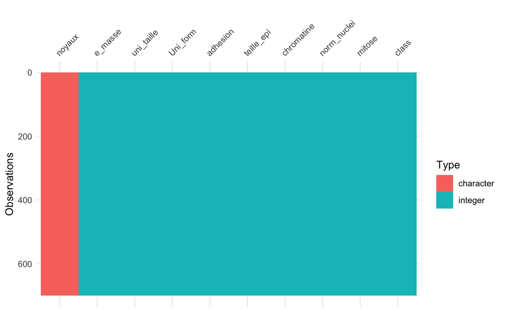

```r
vis_dat(df)
```

So what about the noyaux variable ? :

```r
unique(df$noyaux)
```

```
 [1] "1"  "10" "2"  "4"  "3"  "9"  "7"  "?"  "5"  "8"  "6"
```

With a look at the dataset we notice that the variable noyaux should has an integer type too :

```r
df$noyaux <- as.integer(df$noyaux)
```

```
NAs introduits lors de la conversion automatique
```

We make sure the conversion went well :

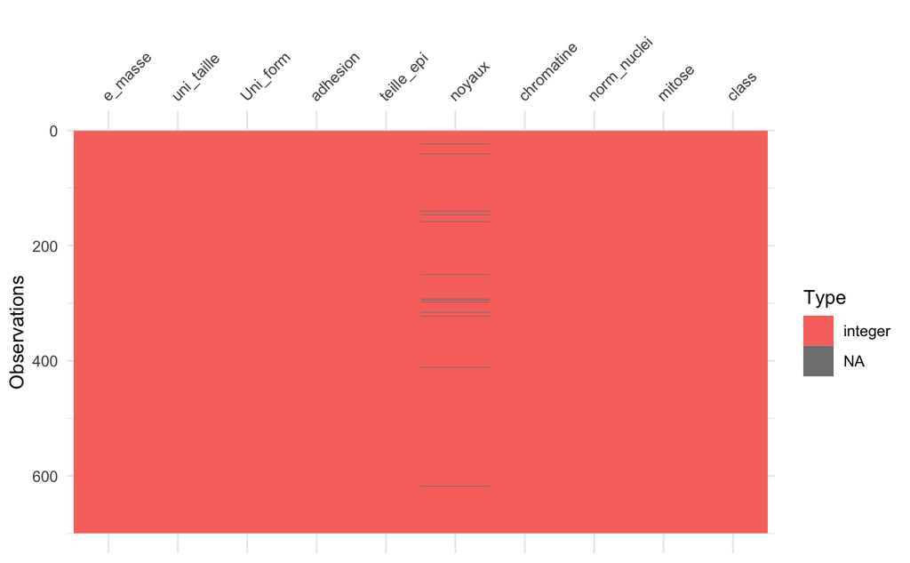

```r
vis_dat(df)
```

We replace the NA with the mean of the values of noyaux and make sure the replacement went well :

```r
m <- mean(df$noyaux, na.rm= TRUE)
df$noyaux[is.na(df$noyaux)] <- m
sum(is.na(df$noyaux))
```

```
[1] 0
```

The variable noyaux has now a numeric type.

2. Statistics

2.1 Statistics univariate unstratified

The variable class records the diagnosis (2 : Benin, 4 : Malin) :

```r
df$class <- factor(df$class)
```

There are about twice more benin diagnosis than malin diagnosis :

```r
table(df$class)
```

```
  2   4
458 241
```

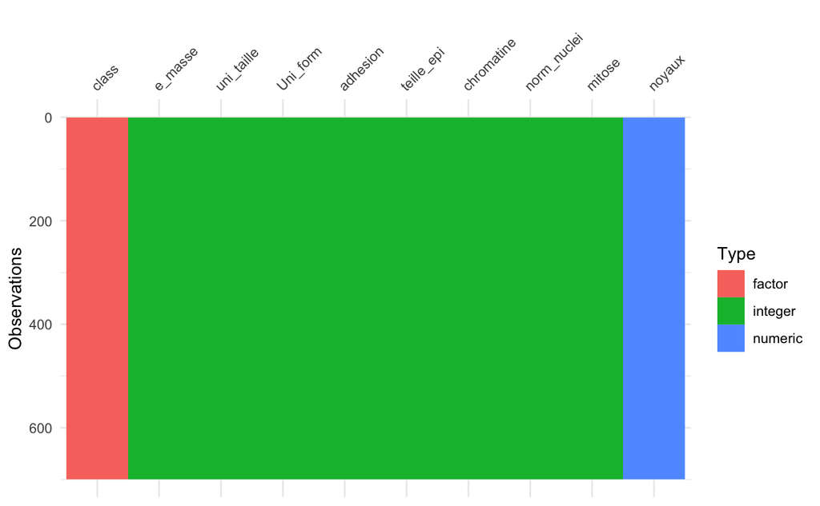

```r
vis_dat(df)
```

```r
summary(df)
```

```
    e_masse         uni_taille        Uni_form         adhesion        teille_epi
 Min.   : 1.000   Min.   : 1.000   Min.   : 1.000   Min.   : 1.000   Min.   : 1.000
 1st Qu.: 2.000   1st Qu.: 1.000   1st Qu.: 1.000   1st Qu.: 1.000   1st Qu.: 2.000
 Median : 4.000   Median : 1.000   Median : 1.000   Median : 1.000   Median : 2.000
 Mean   : 4.418   Mean   : 3.134   Mean   : 3.207   Mean   : 2.807   Mean   : 3.216
 3rd Qu.: 6.000   3rd Qu.: 5.000   3rd Qu.: 5.000   3rd Qu.: 4.000   3rd Qu.: 4.000
 Max.   :10.000   Max.   :10.000   Max.   :10.000   Max.   :10.000   Max.   :10.000
     noyaux         chromatine      norm_nuclei         mitose       class
 Min.   : 1.000   Min.   : 1.000   Min.   : 1.000   Min.   : 1.000   2:458
 1st Qu.: 1.000   1st Qu.: 2.000   1st Qu.: 1.000   1st Qu.: 1.000   4:241
 Median : 1.000   Median : 3.000   Median : 1.000   Median : 1.000
 Mean   : 3.545   Mean   : 3.438   Mean   : 2.867   Mean   : 1.589
 3rd Qu.: 5.000   3rd Qu.: 5.000   3rd Qu.: 4.000   3rd Qu.: 1.000
 Max.   :10.000   Max.   :10.000   Max.   :10.000   Max.   :10.000
```

What is the mean of the numeric variables ? :

```r
dfstat <- subset(df, select = -class)
round(colMeans(dfstat),2)
```

```
    e_masse  uni_taille    Uni_form    adhesion  teille_epi      noyaux  chromatine
       4.42        3.13        3.21        2.81        3.22        3.54        3.44
norm_nuclei      mitose
       2.87        1.59
```

What is the standard deviation of the numeric variables ? :

```r
sapply(dfstat, sd)
```

```
    e_masse  uni_taille    Uni_form    adhesion  teille_epi      noyaux  chromatine
   2.815741    3.051459    2.971913    2.855379    2.214300    3.601852    2.438364
norm_nuclei      mitose
   3.053634    1.715078
```

2.1 Statistics univariate stratified

```r
mean_strat <- aggregate(subset(df, select = -class),by = list(df$class), mean)
sd_strat   <- aggregate(subset(df, select = -class),by = list(df$class), sd)
cv_strat   <- aggregate(subset(df, select = -class),by = list(df$class),function(x){return(sd(x)/mean(x)*100)})
print(summary(subset(df, select = -class)))
```

```
    e_masse         uni_taille        Uni_form         adhesion        teille_epi
 Min.   : 1.000   Min.   : 1.000   Min.   : 1.000   Min.   : 1.000   Min.   : 1.000
 1st Qu.: 2.000   1st Qu.: 1.000   1st Qu.: 1.000   1st Qu.: 1.000   1st Qu.: 2.000
 Median : 4.000   Median : 1.000   Median : 1.000   Median : 1.000   Median : 2.000
 Mean   : 4.418   Mean   : 3.134   Mean   : 3.207   Mean   : 2.807   Mean   : 3.216
 3rd Qu.: 6.000   3rd Qu.: 5.000   3rd Qu.: 5.000   3rd Qu.: 4.000   3rd Qu.: 4.000
 Max.   :10.000   Max.   :10.000   Max.   :10.000   Max.   :10.000   Max.   :10.000
     noyaux         chromatine      norm_nuclei         mitose
 Min.   : 1.000   Min.   : 1.000   Min.   : 1.000   Min.   : 1.000
 1st Qu.: 1.000   1st Qu.: 2.000   1st Qu.: 1.000   1st Qu.: 1.000
 Median : 1.000   Median : 3.000   Median : 1.000   Median : 1.000
 Mean   : 3.545   Mean   : 3.438   Mean   : 2.867   Mean   : 1.589
 3rd Qu.: 5.000   3rd Qu.: 5.000   3rd Qu.: 4.000   3rd Qu.: 1.000
 Max.   :10.000   Max.   :10.000   Max.   :10.000   Max.   :10.000
```

Vizualisations :

```r
i <- 9
# colors
col  <- c('blue', 'red', 'pink' , 'purple' )
par(mfrow = c(1,3)) ;
boxplot(df[,i]~df$class,
        las = 2,
        col = col,
        cex.main = 0.8, main = names(df)[i])

# histograms
hist(df[,i],
     nclass = 30,
     main   = paste0(names(df)[i]) ,
     xlab   = 'values',
     col    = 'blue',
     cex.main = 0.8)
```

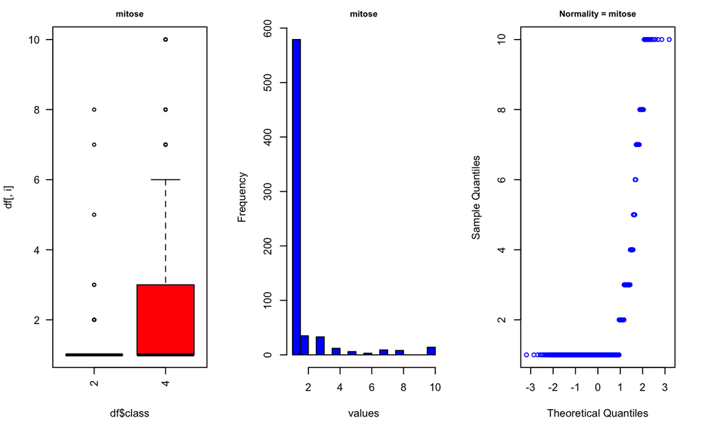

```r
# pplot
qqnorm(df[,i], col = 'blue', cex = 0.8,
       cex.main = 0.8,
       main = paste0('Normality = ', names(df)[i]))
```

From what we can see we can say that for instance almost all of the benin diagnosis are for a mitose of 1, and the distribution of the mitose values is very asymetrical and concentrated on 1.

2.2 Correlations

```r
cor(dfstat)
```

```
              e_masse uni_taille  Uni_form  adhesion teille_epi    noyaux chromatine
e_masse     1.0000000  0.6449125 0.6545891 0.4863562  0.5218162 0.5872997  0.5584282
uni_taille  0.6449125  1.0000000 0.9068819 0.7055818  0.7517991 0.6868014  0.7557210
Uni_form    0.6545891  0.9068819 1.0000000 0.6830792  0.7196684 0.7096058  0.7359485
adhesion    0.4863562  0.7055818 0.6830792 1.0000000  0.5995991 0.6650492  0.6667153
teille_epi  0.5218162  0.7517991 0.7196684 0.5995991  1.0000000 0.5812613  0.6161018
noyaux      0.5872997  0.6868014 0.7096058 0.6650492  0.5812613 1.0000000  0.6758956
chromatine  0.5584282  0.7557210 0.7359485 0.6667153  0.6161018 0.6758956  1.0000000
norm_nuclei 0.5358345  0.7228648 0.7194463 0.6033524  0.6288807 0.5773618  0.6658778
mitose      0.3500339  0.4586931 0.4389109 0.4176328  0.4791015 0.3387402  0.3441695
            norm_nuclei    mitose
e_masse       0.5358345 0.3500339
uni_taille    0.7228648 0.4586931
Uni_form      0.7194463 0.4389109
adhesion      0.6033524 0.4176328
teille_epi    0.6288807 0.4791015
noyaux        0.5773618 0.3387402
chromatine    0.6658778 0.3441695
norm_nuclei   1.0000000 0.4283357
mitose        0.4283357 1.0000000
```

From what we can see many variables have a high correlation with each other :

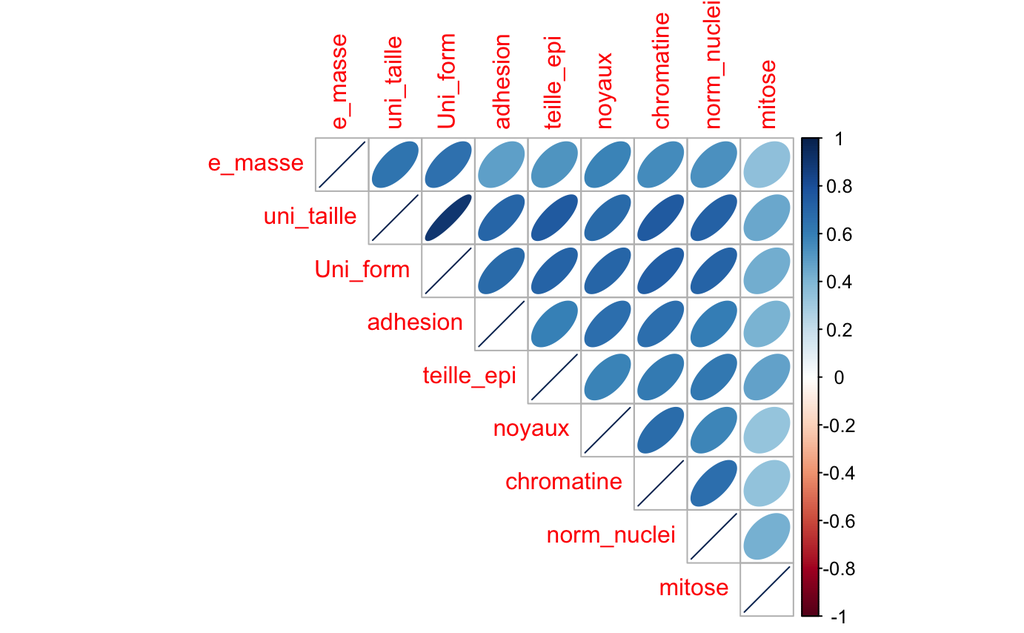

```r
corrplot(cor(dfstat), method = 'ellipse', type = 'upper')
```

For instance, (and as we could expect) the aspect of the nucleus (norm_nuclei) is positively correlated with the uniformity of the cell size and with the uniformity of the cell shape. An other expected observation is the correlation between the aspect of the chromatin (chromatine) and the uniformity of the cell size and shape.

3. PCA

3.1 Inertia

```r
df$class <- as.integer(df$class)
acp <- PCA(df, scale.unit = T, quali.sup = c(1), graph = F)
# acp est un objet composée d'un ensemble de listes R
inertie <- acp$eig
inertie
```

```
       eigenvalue percentage of variance cumulative percentage of variance
comp 1 6.20365362             68.9294847                          68.92948
comp 2 0.78664121              8.7404579                          77.66994
comp 3 0.46984780              5.2205311                          82.89047
comp 4 0.38137681              4.2375201                          87.12799
comp 5 0.35844363              3.9827070                          91.11070
comp 6 0.29733282              3.3036980                          94.41440
comp 7 0.27290023              3.0322248                          97.44662
comp 8 0.14148777              1.5720864                          99.01871
comp 9 0.08831611              0.9812901                         100.00000
```

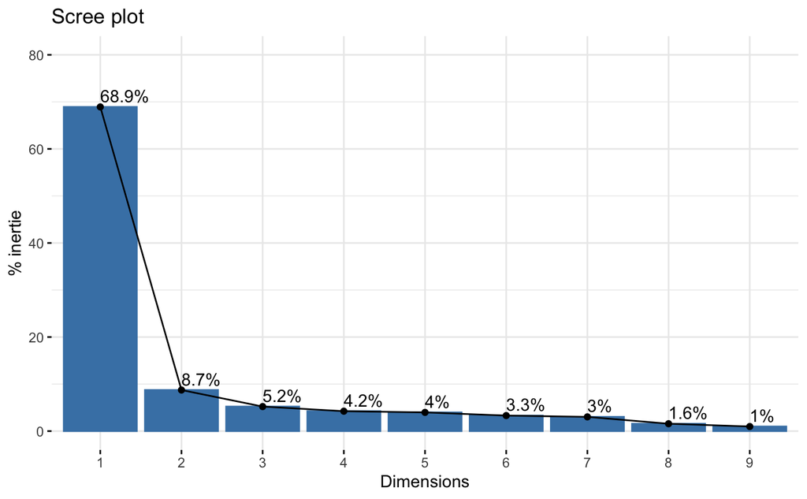

```r
h <- fviz_eig(acp, addlabels = T, ylim = c(0,80), ylab = c('% inertie'))
print(h)
```

Based on Kaiser’s rule the 1rst axis should be chosen (eigen value > 1) :

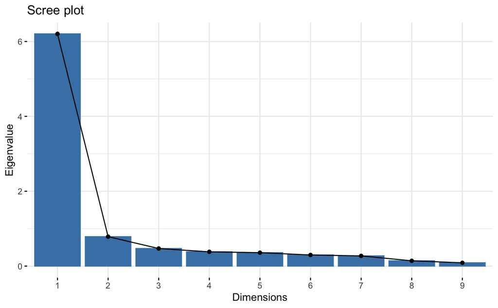

```r
fviz_eig(acp, choice='eigenvalue')
```

3.2 Quality of a plot on axes 1-2

We get the coordinates of the variables on axes 1-2 :

```r
acp$var$coord[,1:2]
```

[output not shown]

Are the variables “well explained” by the axes 1-2 ?

```r
apply(acp$var$cos2[,1:2],1,sum)
```

[output not shown]

Most of the variables are well explained on the 2 axes (around 80%) : mitose, class and uni_taille are the most well explained, and the less well explained are adhesion and norm_nuclei but it is about 67%, so it is acceptable.

We can see the explanation on each axis :

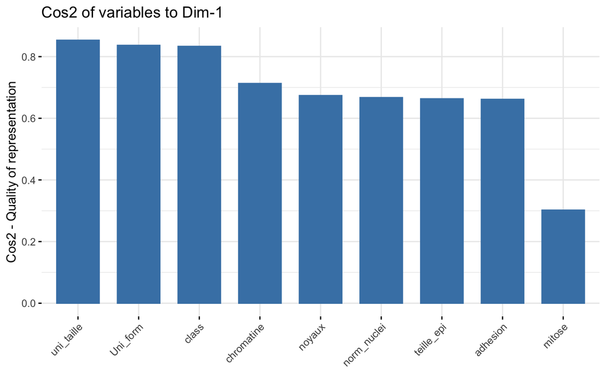

```r
fviz_cos2(acp, choice = "var", axes = 1)
```

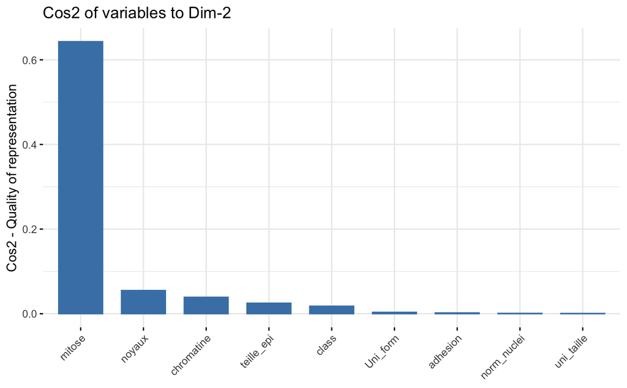

```r
fviz_cos2(acp, choice = "var", axes = 2)
```

It seems that the axis 2 explains largely but also almost exclusively mitose. We can wonder if the axis has a such good quality only “because of” mitose and so on if the axis 3 could be a better compromise :

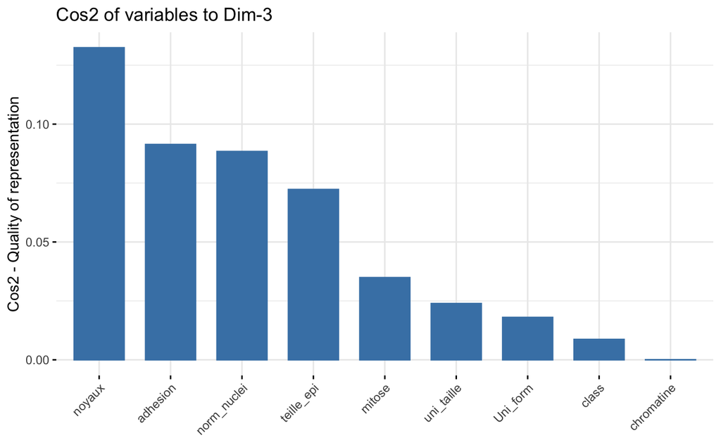

```r
fviz_cos2(acp, choice = "var", axes = 3)
```

The quality of representation is indeed more evenly distributed among the variables. We will question the relevance of axes 1-3 by comparing with axes 1-2 when doing projections.

3.3 Projection on axes 1-2

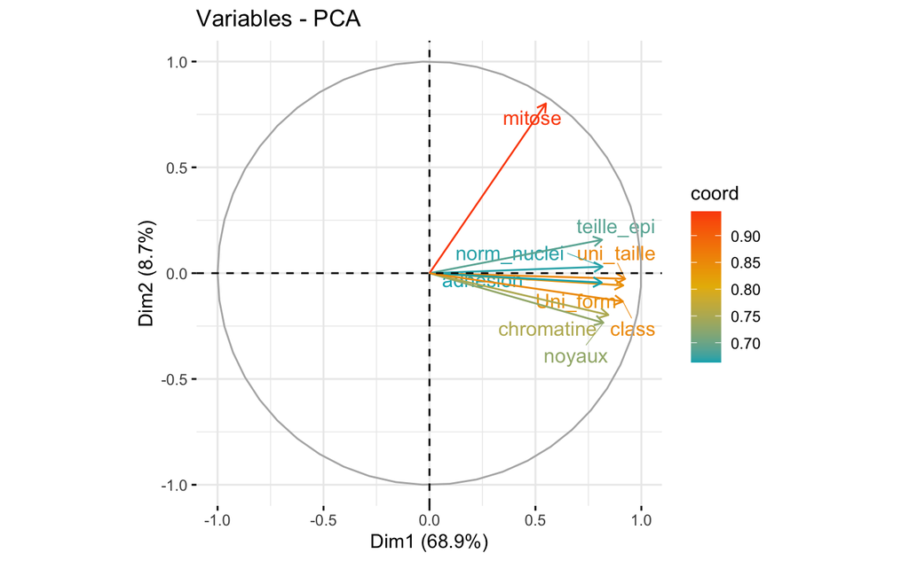

```r
fviz_pca_var(acp, axes = c(1, 2), col.var = "coord",
             gradient.cols = c("#00AFBB", "#E7B800", "#FC4E07"),
             repel = TRUE )
```

Axis 2 would oppose patients with a high mitose type and teill_epi with patients with low noyaux, chromatine and class. Globally the quality of the representation it not very good, it doesn’t allow to distinguish groups very easily.

As we wonder if axis 2 was “great” only thanks to mitose we compare the projection with axes 1-3 :

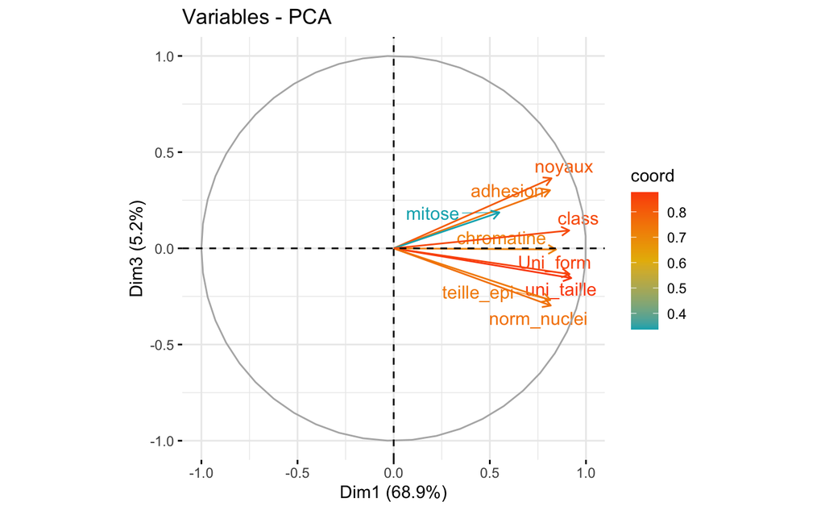

```r
fviz_pca_var(acp, axes = c(1, 3), col.var = "coord",
             gradient.cols = c("#00AFBB", "#E7B800", "#FC4E07"),
             repel = TRUE )
```

3.4 Projection on axes 1-2 or 1-3

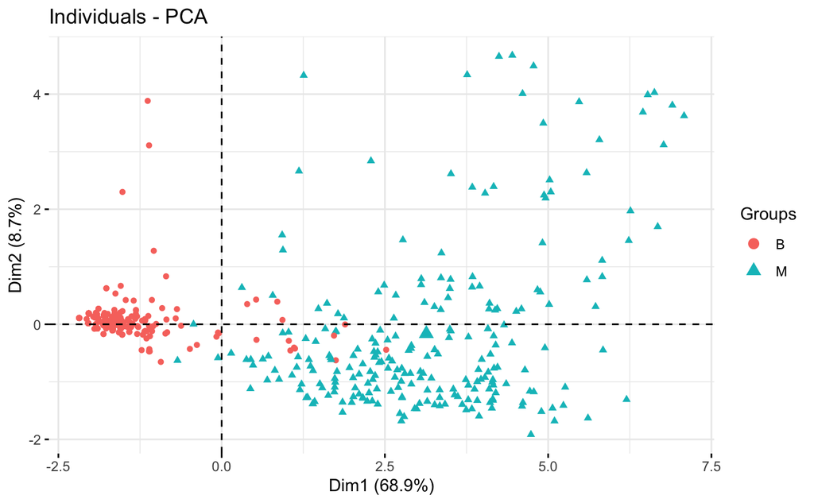

```r
df$class <- mapvalues(df$class,
          from=c("1","2"),
          to=c("B","M"))
fviz_pca_ind(acp, axes = c(1, 2),
             geom.ind = "point",
             col.ind =df$class, # color by groups
             addEllipses = F, # Concentration ellipses
             legend.title = "Groups"
)
```

In the 2D representation the distribution between malign and benign patients is different but we should have a look on axes 1-3.

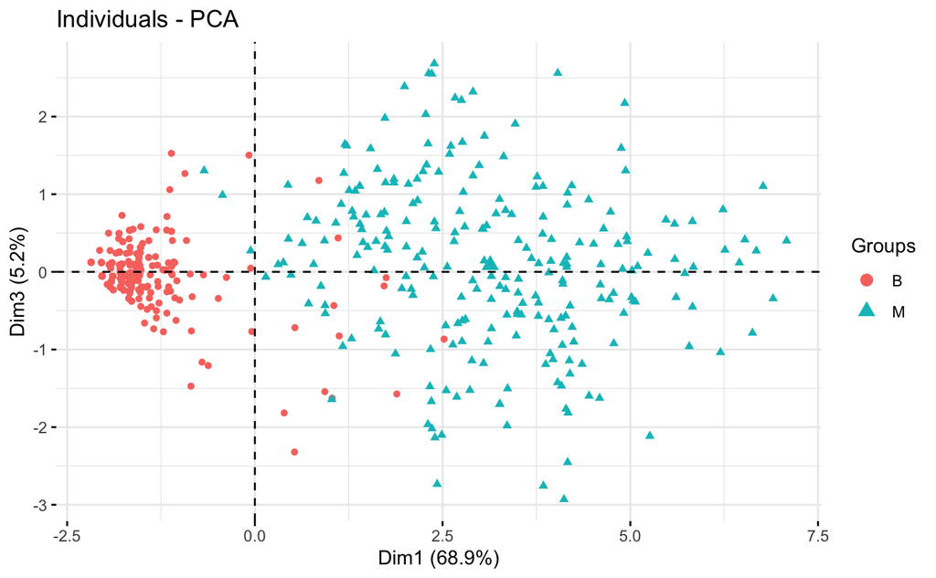

```r
fviz_pca_ind(acp, axes = c(1, 3),
             geom.ind = "point",
             col.ind =df$class, # color by groups
             addEllipses = F, # Concentration ellipses
             legend.title = "Groups"
)
```

3.5 Biplot

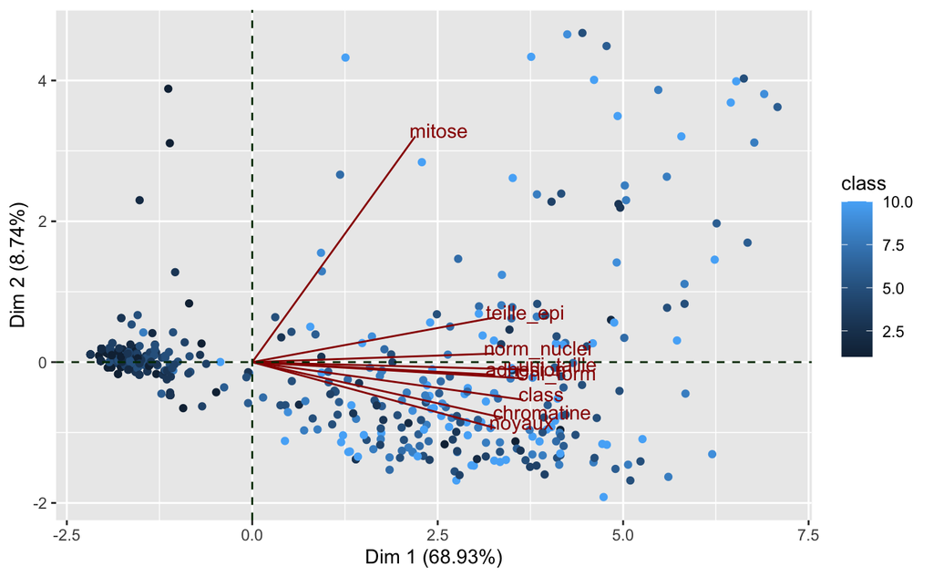

```r
PCA_Biplot = function(pca , df, qualisup = NULL, axes = c(1,2), cos2 = 0, ncp = 7 )
{
  scale <- 4
  varX <- pca$var$coord[,axes[1]]; varcosX =  pca$var$cos2[,axes[1]]
  varY <- pca$var$coord[,axes[2]]; varcosY =  pca$var$cos2[,axes[2]]
  #-> qualité de représentation dans le plan
  cosT <- varcosX + varcosY
  id   <- which(cosT > cos2)
  Vp   <- pca$svd$V[id,axes]
  lam  <- matrix(pca$eig[axes,1],ncol = length(pca$eig[axes,1]), nrow = length(id), byrow = T)
  tab  <- pca$var$coord[id,axes]
  ind  <- data.frame(pca$ind$coor[,axes],'class' = df[,qualisup])
  names(ind) <- c('X','Y', 'class')
  g <- ggplot() + geom_point(data = ind,aes(x = X, y = Y, color = class))
  g <- g + geom_segment(aes(x = rep(0,nrow(tab)), y = rep(0,nrow(tab)), xend = scale*tab[,1],yend = scale*tab[,2]), color = '#990000')
  g <- g + geom_text(aes(x =scale*tab[,1], y = scale*tab[,2]), label = rownames(tab), hjust = 0.1, vjust = 0.1, color = '#990000' )
  g <- g + geom_hline(yintercept = 0, colour = '#003300', linetype = 2 )
  g <- g + geom_vline(xintercept = 0, colour = '#003300', linetype = 2 )
  g <- g + xlab(paste0('Dim ',axes[1] ,' (', round(pca$eig[axes[1],2], digits = 2 ), '%)' ))
  g <- g + ylab(paste0('Dim ',axes[2] ,' (', round(pca$eig[axes[2],2], digits = 2 ), '%)' ))
  n <- colnames(pca$ind$coord[,axes])
   return(g)
}
g <- PCA_Biplot(pca = acp, df = df , qualisup = 1)
print(g)
```

3.5 Partitioning

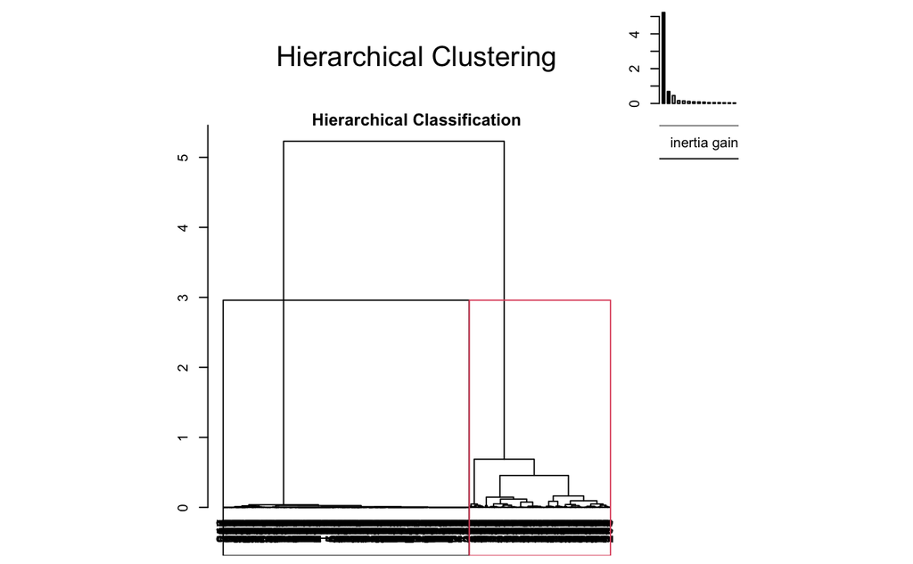

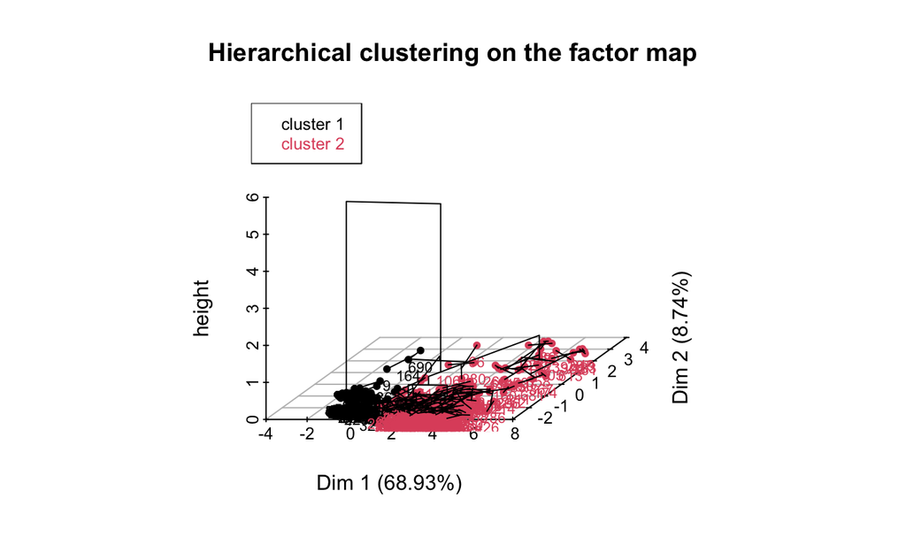

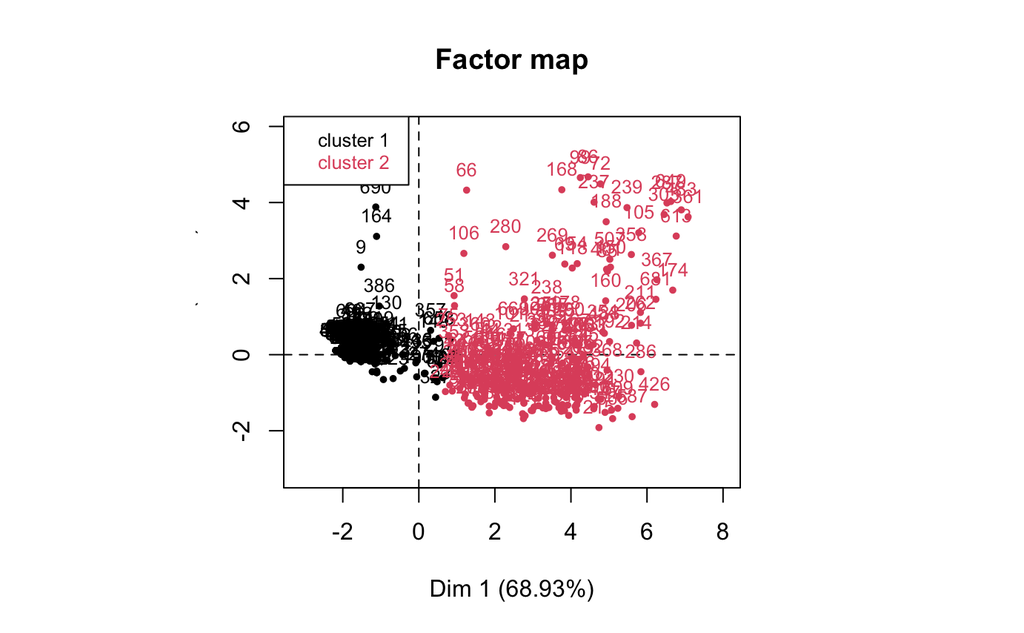

```r
res.cah = HCPC(acp, graph=T, nb.clust = 2)
```

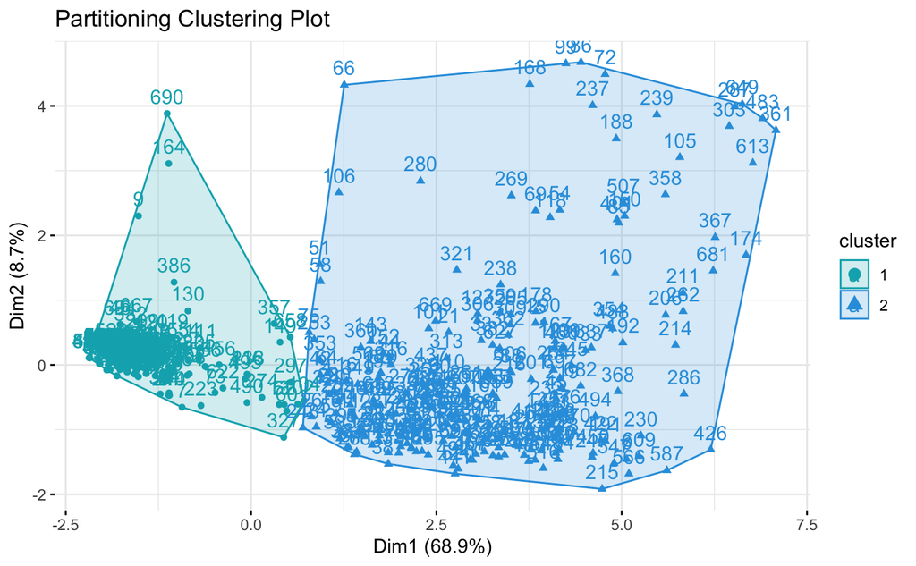

```r
fviz_cluster(res.cah, data = df,
             palette = c("#00AFBB","#2E9FDF", "#E7B800", "#FC4E07"),
             ggtheme = theme_minimal(),
             main = "Partitioning Clustering Plot"
             )
```

To go further we can test our choice to test a classification model :

```r
gold <- factor(df$class)
predacp <- factor(res.cah$data.clust[,9], levels = c(2,1), labels= c('B','M'))
confusionMatrix(predacp,gold)
```

```
Confusion Matrix and Statistics

          Reference
Prediction   B   M
         B   8  27
         M 445 134

               Accuracy : 0.2313
                 95% CI : (0.1985, 0.2667)
    No Information Rate : 0.7378
    P-Value [Acc > NIR] : 1

                  Kappa : -0.0817

 Mcnemar's Test P-Value : <2e-16

            Sensitivity : 0.01766
            Specificity : 0.83230
         Pos Pred Value : 0.22857
         Neg Pred Value : 0.23143
             Prevalence : 0.73779
         Detection Rate : 0.01303
   Detection Prevalence : 0.05700
      Balanced Accuracy : 0.42498

       'Positive' Class : B
```

The accuracy is not very good (23%), specially because of a poor sensitivity and detection rate.